# RepRes_prog2

jjperez

Monday, June 15, 2015

Title:

# Tornados and Floods the most dangerous atmospheric events for the people and the economy

# 0. Sinopsis

Along this report a set of data from U.S. National Oceanic and Atmospheric Administration’s (NOAA) storm database has been analized. The objective of this analysis was determinate which atmosferic event, between the 48 categories admited on the batabase, was the most dangerous in terms of diseases and billions of dollar. The values for the categories was not normalized into the data base so before begin the analysis it was necessary to process and normalize this data. The same problem appeared on the columns for the exponent when analizing the economical impact of every event.

The results of this analysis shows the worst event in term os diseases are the **Tornados**, with more than 90000 casualities. In the hand **Flood** was the most dangerous event in general terms (total loss) as well as terms of value for damaged properties. **Drought** appears as the most dangerous event in terms of damaged crop value loss.

# 1. Data Processing

Pior downloading the data, and working with it, it is neccesary to load the following packages into R:

```r
library(lubridate, quietly = TRUE)
library(RColorBrewer, quietly = TRUE)
library(lattice, quietly = TRUE)
library(xtable, quietly = TRUE)
library(knitr, quietly = TRUE)
library(dplyr, quietly = TRUE)
```

The data for this report comes from the U.S. National Weather Service Storm Data Base. This database Data has been downloaded from a repository prepared for the “Reproducible Research Course” at Coursera. The following code has been used to download the file into the working directory.

```r
url <- "https://d396qusza40orc.cloudfront.net/repdata%2Fdata%2FStormData.csv.bz2"
download.file(url,"StormData.csv.bz2")
```

In the following links you can find some documentation of the database available:

```
- **[National Weather Service Storm Data Documentation]** (https://d396qusza40orc.cloudfront.net/repdata%2Fpeer2_doc%2Fpd01016005curr.pdf)

- **[National Climatic Data Center Storm Events FAQ]** (https://d396qusza40orc.cloudfront.net/repdata%2Fpeer2_doc%2FNCDC%20Storm%20Events-FAQ%20Page.pdf)
```

Raw Data set is loaded a variable called **“StormData”**.

```r
options(xtable.type = 'html')
StormData <- read.csv("StormData.csv.bz2" , stringsAsFactors = FALSE)
xtable(head(StormData[,1:9]))
```

|  | STATE__ | BGN_DATE | BGN_TIME | TIME_ZONE | COUNTY | COUNTYNAME | STATE | EVTYPE | BGN_RANGE |
| --- | --- | --- | --- | --- | --- | --- | --- | --- | --- |
| 1 | 1.00 | 4/18/1950 0:00:00 | 0130 | CST | 97.00 | MOBILE | AL | TORNADO | 0.00 |
| 2 | 1.00 | 4/18/1950 0:00:00 | 0145 | CST | 3.00 | BALDWIN | AL | TORNADO | 0.00 |
| 3 | 1.00 | 2/20/1951 0:00:00 | 1600 | CST | 57.00 | FAYETTE | AL | TORNADO | 0.00 |
| 4 | 1.00 | 6/8/1951 0:00:00 | 0900 | CST | 89.00 | MADISON | AL | TORNADO | 0.00 |
| 5 | 1.00 | 11/15/1951 0:00:00 | 1500 | CST | 43.00 | CULLMAN | AL | TORNADO | 0.00 |
| 6 | 1.00 | 11/15/1951 0:00:00 | 2000 | CST | 77.00 | LAUDERDALE | AL | TORNADO | 0.00 |

After looking into the data it has been necessary normalize the given data for the Event Type (EVTYPE) column. NOAA admits up to 48 normalized categories, however in the actual value data set there are up to 985 different cases. Also the exponents to calculte the value for damaged properties and crops has been introduced as character chains. It is neccesary to substitu these characters for their numeric values in order to calculate the total economical impact.

Do to the size of the given data the first will be preselect just the necessary columns to carry on with the analysis.

```r
StormData<- StormData[complete.cases(StormData[,c("EVTYPE","FATALITIES","INJURIES", "PROPDMG","PROPDMGEXP","CROPDMG","CROPDMGEXP")]),c("EVTYPE","FATALITIES","INJURIES","PROPDMG","PROPDMGEXP","CROPDMG","CROPDMGEXP")]
```

## 1.1. Normalizing the Event Type (EVTYPE)

This is how EVTYPE looks now:

```r
options(xtable.type = 'html')
List <- unique(StormData$EVTYPE)
xtable(head(as.data.frame(List)))
```

|  | List |
| --- | --- |
| 1 | TORNADO |
| 2 | TSTM WIND |
| 3 | HAIL |
| 4 | FREEZING RAIN |
| 5 | SNOW |
| 6 | ICE STORM/FLASH FLOOD |

To remove the invalid categories I have used the funcion grep. In the next chunk of code I have included all the replacement made. I have followed this order:

1. Check all the categories using the same words as I didn´t expect any mistakes on the database. During this process all the blanks have been removed and the words merged together to make easier next steps.

```r
StormData[ (grep( pattern = "Winter Weather" , x = StormData$EVTYPE, ignore.case = TRUE) ), "EVTYPE"] <- c("WinterWeather")
StormData[ (grep( pattern = "Winter Storm" , x = StormData$EVTYPE, ignore.case = TRUE) ), "EVTYPE"] <- c("WinterStorm")
StormData[ (grep( pattern = "Wildfire" , x = StormData$EVTYPE, ignore.case = TRUE) ), "EVTYPE"] <- c("Wildfire")
StormData[ (grep( pattern = "Waterspout" , x = StormData$EVTYPE, ignore.case = TRUE) ), "EVTYPE"] <- c("Waterspout")
StormData[ (grep( pattern = "Ash" , x = StormData$EVTYPE, ignore.case = TRUE) ), "EVTYPE"] <- c("VolcanicAsh")
StormData[ (grep( pattern = "Tsunami" , x = StormData$EVTYPE, ignore.case = TRUE) ), "EVTYPE"] <- c("Tsunami")
StormData[ (grep( pattern = "Tropical Storm" , x = StormData$EVTYPE, ignore.case = TRUE) ), "EVTYPE"] <- c("TropicalStorm")
StormData[ (grep( pattern = "Depression" , x = StormData$EVTYPE, ignore.case = TRUE) ), "EVTYPE"] <- c("TropicalDepression")
StormData[ (grep( pattern = "Tornado" , x = StormData$EVTYPE, ignore.case = TRUE) ), "EVTYPE"] <- c("Tornado")
StormData[ (grep( pattern = "Thunderstorm Win" , x = StormData$EVTYPE, ignore.case = TRUE) ), "EVTYPE"] <- c("ThunderstormWind")
StormData[ (grep( pattern = "Strong Wind" , x = StormData$EVTYPE, ignore.case = TRUE) ), "EVTYPE"] <- c("StrongWind")
StormData[ (grep( pattern = "Storm " , x = StormData$EVTYPE, ignore.case = TRUE) ), "EVTYPE"] <- c("StrongSurgeTide")
StormData[ (grep( pattern = "Sleet" , x = StormData$EVTYPE, ignore.case = TRUE) ), "EVTYPE"] <- c("Sleet")
StormData[ (grep( pattern = "Seiche" , x = StormData$EVTYPE, ignore.case = TRUE) ), "EVTYPE"] <- c("Seiche")
StormData[ (grep( pattern = "Rip Current" , x = StormData$EVTYPE, ignore.case = TRUE) ), "EVTYPE"] <- c("RipCurrent")
StormData[ (grep( pattern = "Marine Thunderstorm" , x = StormData$EVTYPE, ignore.case = TRUE) ), "EVTYPE"] <- c("Marine.Thunderstorm")
StormData[ (grep( pattern = "Marine Strong Win" , x = StormData$EVTYPE, ignore.case = TRUE) ), "EVTYPE"] <- c("MarineStrongWind")
StormData[ (grep( pattern = "Marine High Win" , x = StormData$EVTYPE, ignore.case = TRUE) ), "EVTYPE"] <- c("MarineHighWind")
StormData[ (grep( pattern = "Marine Hail" , x = StormData$EVTYPE, ignore.case = TRUE) ), "EVTYPE"] <- c("MarineHail")
StormData[ (grep( pattern = "Lightning" , x = StormData$EVTYPE, ignore.case = TRUE) ), "EVTYPE"] <- c("Lightning")
StormData[ (grep( pattern = "Lakeshore" , x = StormData$EVTYPE, ignore.case = TRUE) ), "EVTYPE"] <- c("LakeshoreFlood")
StormData[ (grep( pattern = "Lake-Effect Snow" , x = StormData$EVTYPE, ignore.case = TRUE) ), "EVTYPE"] <- c("LakeEffectSnow")
StormData[ (grep( pattern = "Ice " , x = StormData$EVTYPE, ignore.case = TRUE) ), "EVTYPE"] <- c("IceStorm")
StormData[ (grep( pattern = "Typhoon " , x = StormData$EVTYPE, ignore.case = TRUE) ), "EVTYPE"] <- c("HurricaneTyphoon")
StormData[ (grep( pattern = "Hurricane" , x = StormData$EVTYPE, ignore.case = TRUE) ), "EVTYPE"] <- c("HurricaneTyphoon")
StormData[ (grep( pattern = "High Wind" , x = StormData$EVTYPE, ignore.case = TRUE) ), "EVTYPE"] <- c("HighWind")
StormData[ (grep( pattern = "High Surf" , x = StormData$EVTYPE, ignore.case = TRUE) ), "EVTYPE"] <- c("HighSurf")
StormData[ (grep( pattern = "Heavy Snow" , x = StormData$EVTYPE, ignore.case = TRUE) ), "EVTYPE"] <- c("HeavySnow")
StormData[ (grep( pattern = "Heavy Rain" , x = StormData$EVTYPE, ignore.case = TRUE) ), "EVTYPE"] <- c("HeavyRain")
StormData[ (grep( pattern = "Heat" , x = StormData$EVTYPE, ignore.case = TRUE) ), "EVTYPE"] <- c("Heat")
StormData[ (grep( pattern = "Hail" , x = StormData$EVTYPE, ignore.case = TRUE) ), "EVTYPE"] <- c("Hail")
StormData[ (grep( pattern = "Freezing Fog" , x = StormData$EVTYPE, ignore.case = TRUE) ), "EVTYPE"] <- c("FreezingFog")
StormData[ (grep( pattern = "Funnel Cloud" , x = StormData$EVTYPE, ignore.case = TRUE) ), "EVTYPE"] <- c("FunnelCloud")
StormData[ (grep( pattern = "Freeze" , x = StormData$EVTYPE, ignore.case = TRUE) ), "EVTYPE"] <- c("FrostFreeze")
StormData[ (grep( pattern = "Frost" , x = StormData$EVTYPE, ignore.case = TRUE) ), "EVTYPE"] <- c("FrostFreeze")
StormData[ (grep( pattern = "Flash Flood" , x = StormData$EVTYPE, ignore.case = TRUE) ), "EVTYPE"] <- c("FlashFlood")
StormData[ (grep( pattern = "Coastal Flood" , x = StormData$EVTYPE, ignore.case = TRUE) ), "EVTYPE"] <- c("CoastalFlood")
StormData[ (grep( pattern = "Flood" , x = StormData$EVTYPE, ignore.case = TRUE) ), "EVTYPE"] <- c("Flood")
StormData[ (grep( pattern = "Extreme Cold" , x = StormData$EVTYPE, ignore.case = TRUE) ), "EVTYPE"] <- c("ExtremeColdWindChill")
StormData[ (grep( pattern = "Wind Chill" , x = StormData$EVTYPE, ignore.case = TRUE) ), "EVTYPE"] <- c("ExtremeColdWindChill")
StormData[ (grep( pattern = "Excessive Heat" , x = StormData$EVTYPE, ignore.case = TRUE) ), "EVTYPE"] <- c("ExcessiveHeat")
StormData[ (grep( pattern = "Dust Storm" , x = StormData$EVTYPE, ignore.case = TRUE) ), "EVTYPE"] <- c("DustStorm")
StormData[ (grep( pattern = "Dust Devil" , x = StormData$EVTYPE, ignore.case = TRUE) ), "EVTYPE"] <- c("DustDevil")
StormData[ (grep( pattern = "Drought" , x = StormData$EVTYPE, ignore.case = TRUE) ), "EVTYPE"] <- c("Drought")
StormData[ (grep( pattern = "Dense Smoke" , x = StormData$EVTYPE, ignore.case = TRUE) ), "EVTYPE"] <- c("DenseSmoke")
StormData[ (grep( pattern = "Dense Fog" , x = StormData$EVTYPE, ignore.case = TRUE) ), "EVTYPE"] <- c("DenseFog")
StormData[ (grep( pattern = "Debris Flow" , x = StormData$EVTYPE, ignore.case = TRUE) ), "EVTYPE"] <- c("DebrisFlow")
StormData[ (grep( pattern = "Blizzard" , x = StormData$EVTYPE, ignore.case = TRUE) ), "EVTYPE"] <- c("Blizzard")
StormData[ (grep( pattern = "Avalanche" , x = StormData$EVTYPE, ignore.case = TRUE) ), "EVTYPE"] <- c("Avalanche")
StormData[ (grep( pattern = "Astronomical" , x = StormData$EVTYPE, ignore.case = TRUE) ), "EVTYPE"] <- c("AstronomicalLowTide")
```

In the next step I have focus on the categories with typos and words that can be considered similar to existing categories. Due to same categories are quite similar (WIND, STRONG WIND, HIGH WIND) it has been necessary to find the correct order for this serie of commands.

```r
StormData[ (grep( pattern = "Snow" , x = StormData$EVTYPE, ignore.case = TRUE) ), "EVTYPE"] <- c("HeavySnow")
StormData[ (grep( pattern = "Lighting" , x = StormData$EVTYPE, ignore.case = TRUE) ), "EVTYPE"] <- c("Lightning")
StormData[ (grep( pattern = "Record Cold" , x = StormData$EVTYPE, ignore.case = TRUE) ), "EVTYPE"] <- c("ExtremeColdWindChill")
StormData[ (grep( pattern = "Funnel" , x = StormData$EVTYPE, ignore.case = TRUE) ), "EVTYPE"] <- c("FunnelCloud")
StormData[ (grep( pattern = "Cold" , x = StormData$EVTYPE, ignore.case = TRUE) ), "EVTYPE"] <- c("ColdWindChill")
StormData[ (grep( pattern = "Record High" , x = StormData$EVTYPE, ignore.case = TRUE) ), "EVTYPE"] <- c("ExcessiveHeat")
StormData[ (grep( pattern = "High Seas" , x = StormData$EVTYPE, ignore.case = TRUE) ), "EVTYPE"] <- c("AstronomicalLowTide")
StormData[ (grep( pattern = "High Tides" , x = StormData$EVTYPE, ignore.case = TRUE) ), "EVTYPE"] <- c("AstronomicalLowTide")
StormData[ (grep( pattern = "Heavy Precipatation" , x = StormData$EVTYPE, ignore.case = TRUE) ), "EVTYPE"] <- c("HeavyRain")
StormData[ (grep( pattern = "Wild Fires" , x = StormData$EVTYPE, ignore.case = TRUE) ), "EVTYPE"] <- c("Wildfires")
StormData[ (grep( pattern = "Low Temperature Record" , x = StormData$EVTYPE, ignore.case = TRUE) ), "EVTYPE"] <- c("ExtremeColdWindChill")
StormData[ (grep( pattern = "Record Rainfall" , x = StormData$EVTYPE, ignore.case = TRUE) ), "EVTYPE"] <- c("HeavyRain")
StormData[ (grep( pattern = "Record Warmth" , x = StormData$EVTYPE, ignore.case = TRUE) ), "EVTYPE"] <- c("ExcessiveHeat")
StormData[ (grep( pattern = "High Record" , x = StormData$EVTYPE, ignore.case = TRUE) ), "EVTYPE"] <- c("ExcessiveHeat")
StormData[ (grep( pattern = "High winds" , x = StormData$EVTYPE, ignore.case = TRUE) ), "EVTYPE"] <- c("HeavyWind")
StormData[ (grep( pattern = "Hypothermia" , x = StormData$EVTYPE, ignore.case = TRUE) ), "EVTYPE"] <- c("ExtremeColdWindChill")
StormData[ (grep( pattern = "TSTM" , x = StormData$EVTYPE, ignore.case = TRUE) ), "EVTYPE"] <- c("ThunderstormWind")
StormData[ (grep( pattern = "Dry" , x = StormData$EVTYPE, ignore.case = TRUE) ), "EVTYPE"] <- c("Drought")
StormData[ (grep( pattern = "Warmth" , x = StormData$EVTYPE, ignore.case = TRUE) ), "EVTYPE"] <- c("ExcessiveHeat")
StormData[ (grep( pattern = "Volcanic" , x = StormData$EVTYPE, ignore.case = TRUE) ), "EVTYPE"] <- c("VolcanicAsh")
StormData[ (grep( pattern = "Severe Thunderstorm" , x = StormData$EVTYPE, ignore.case = TRUE) ), "EVTYPE"] <- c("ThunderstorWind")
StormData[ (grep( pattern = "Thunderstorm" , x = StormData$EVTYPE, ignore.case = TRUE) ), "EVTYPE"] <- c("ThunderstorWind")
StormData[ (grep( pattern = "Microburst" , x = StormData$EVTYPE, ignore.case = TRUE) ), "EVTYPE"] <- c("StrongWing")
StormData[ (grep( pattern = "Waytersput" , x = StormData$EVTYPE, ignore.case = TRUE) ), "EVTYPE"] <- c("Waterspout")
StormData[ (grep( pattern = "Ice" , x = StormData$EVTYPE, ignore.case = TRUE) ), "EVTYPE"] <- c("IceStorm")
StormData[ (grep( pattern = "Fire" , x = StormData$EVTYPE, ignore.case = TRUE) ), "EVTYPE"] <- c("Wildfire")
StormData[ (grep( pattern = "Thunderstorm." , x = StormData$EVTYPE, ignore.case = TRUE) ), "EVTYPE"] <- c("ThunderstormWind")
StormData[ (grep( pattern = "Icy" , x = StormData$EVTYPE, ignore.case = TRUE) ), "EVTYPE"] <- c("IceStorm")
StormData[ (grep( pattern = "Surf" , x = StormData$EVTYPE, ignore.case = TRUE) ), "EVTYPE"] <- c("HighSurf")
StormData[ (grep( pattern = "WindChill" , x = StormData$EVTYPE, ignore.case = TRUE) ), "EVTYPE"] <- c("ExtremeColdWindChill")
StormData[ (grep( pattern = "Freezing Rain" , x = StormData$EVTYPE, ignore.case = TRUE) ), "EVTYPE"] <- c("Sleet")
StormData[ (grep( pattern = "Hyperthermia(.*)" , x = StormData$EVTYPE, ignore.case = TRUE) ), "EVTYPE"] <- c("ExcessiveHeat")
StormData[ (grep( pattern = "Driest" , x = StormData$EVTYPE, ignore.case = TRUE) ), "EVTYPE"] <- c("Drought")
StormData[ (grep( pattern = "Record(.*)Cool" , x = StormData$EVTYPE, ignore.case = TRUE) ), "EVTYPE"] <- c("ExtremeColdWindChill")
StormData[ (grep( pattern = "Record(.*)Warm" , x = StormData$EVTYPE, ignore.case = TRUE) ), "EVTYPE"] <- c("ExcessiveHeat")
StormData[ (grep( pattern = "Record(.*)Precipitation" , x = StormData$EVTYPE, ignore.case = TRUE) ), "EVTYPE"] <- c("HeavyRain")
StormData[ (grep( pattern = "Unseasonable(.*)Warm(.*)" , x = StormData$EVTYPE, ignore.case = TRUE) ), "EVTYPE"] <- c("ExcessiveHeat")
StormData[ (grep( pattern = "Unseasonable(.*)Hot" , x = StormData$EVTYPE, ignore.case = TRUE) ), "EVTYPE"] <- c("ExcessiveHeat")
StormData[ (grep( pattern = "(.*)DUst(.*)" , x = StormData$EVTYPE, ignore.case = TRUE) ), "EVTYPE"] <- c("DustStorm")
StormData[ (grep( pattern = "Warm(.*)Weather" , x = StormData$EVTYPE, ignore.case = TRUE) ), "EVTYPE"] <- c("Heat")
StormData[ (grep( pattern = "(.*)Warm(.*)Wet(.*)" , x = StormData$EVTYPE, ignore.case = TRUE) ), "EVTYPE"] <- c("TropicalDepression")
StormData[ (grep( pattern = "Warm" , x = StormData$EVTYPE, ignore.case = TRUE) ), "EVTYPE"] <- c("ExcessiveHeat")
StormData[ (grep( pattern = "GUSTY LAKE WIND" , x = StormData$EVTYPE, ignore.case = TRUE) ), "EVTYPE"] <- c("LakeEffectSnow")
StormData[ (grep( pattern = "below normal precipitation" , x = StormData$EVTYPE, ignore.case = TRUE) ), "EVTYPE"] <- c("Drought")
StormData[ (grep( pattern = "(.*)High(.)Winds(.*)" , x = StormData$EVTYPE, ignore.case = TRUE) ), "EVTYPE"] <- c("HighWinds")
StormData[ (grep( pattern = "(.*)Shower(.*)" , x = StormData$EVTYPE, ignore.case = TRUE) ), "EVTYPE"] <- c("HeavyRain")
StormData[ (grep( pattern = "(.*)Hot(.*)" , x = StormData$EVTYPE, ignore.case = TRUE) ), "EVTYPE"] <- c("ExcessiveHeat")
StormData[ (grep( pattern = "(.*)Low(.*)Tide." , x = StormData$EVTYPE, ignore.case = TRUE) ), "EVTYPE"] <- c("AstronomicalLowTide")
StormData[ (grep( pattern = "(.*)Low(.*)Tide" , x = StormData$EVTYPE, ignore.case = TRUE) ), "EVTYPE"] <- c("AstronomicalLowTide")
StormData[ (grep( pattern = "(.*)Low(.*)Wind" , x = StormData$EVTYPE, ignore.case = TRUE) ), "EVTYPE"] <- c("Blizzard")
StormData[ (grep( pattern = "(.*)Low(.*)Rainfall" , x = StormData$EVTYPE, ignore.case = TRUE) ), "EVTYPE"] <- c("Drought")
StormData[ (grep( pattern = "(.*)Low(.*)Temp(.*)" , x = StormData$EVTYPE, ignore.case = TRUE) ), "EVTYPE"] <- c("ExtremeColdChillWind")
StormData[ (grep( pattern = "REcord Low" , x = StormData$EVTYPE, ignore.case = TRUE) ), "EVTYPE"] <- c("ExtremeColdChillWind")
StormData[ (grep( pattern = "Marine (.*)" , x = StormData$EVTYPE, ignore.case = TRUE) ), "EVTYPE"] <- NA
StormData[ (grep( pattern = "(.*)tning" , x = StormData$EVTYPE, ignore.case = TRUE) ), "EVTYPE"] <- c("Lightning")
StormData[ (grep( pattern = "W(.*)spout" , x = StormData$EVTYPE, ignore.case = TRUE) ), "EVTYPE"] <- c("Waterspout")
StormData[ (grep( pattern = "Thunder(.*)Wind" , x = StormData$EVTYPE, ignore.case = TRUE) ), "EVTYPE"] <- c("ThunderstormWind")
StormData[ (grep( pattern = "Gusty(.*)Rain" , x = StormData$EVTYPE, ignore.case = TRUE) ), "EVTYPE"] <- c("HeavyRain")
StormData[ (grep( pattern = "Gusty(.*)Wind" , x = StormData$EVTYPE, ignore.case = TRUE) ), "EVTYPE"] <- c("HeavyWind")
StormData[ (grep( pattern = "Typh(.*)" , x = StormData$EVTYPE, ignore.case = TRUE) ), "EVTYPE"] <- c("HurricaneTyphoon")
StormData[ (grep( pattern = "Rock(.*)" , x = StormData$EVTYPE, ignore.case = TRUE) ), "EVTYPE"] <- c("DebrisFlow")
StormData[ (grep( pattern = "Land(.*)spout" , x = StormData$EVTYPE, ignore.case = TRUE) ), "EVTYPE"] <- c("DebrisFlow")
StormData[ (grep( pattern = "(.*)Slide(.*)" , x = StormData$EVTYPE, ignore.case = TRUE) ), "EVTYPE"] <- c("DebrisFlow")
StormData[ (grep( pattern = "(.*)Coast(.*)" , x = StormData$EVTYPE, ignore.case = TRUE) ), "EVTYPE"] <- c("CoastalFlood")
StormData[ (grep( pattern = "Whilrwind" , x = StormData$EVTYPE, ignore.case = TRUE) ), "EVTYPE"] <- c("Tornado")
StormData[ (grep( pattern = "High(.*)wind" , x = StormData$EVTYPE, ignore.case = TRUE) ), "EVTYPE"] <- c("HighWind")
StormData[ (grep( pattern = "Exces(.*)Rain" , x = StormData$EVTYPE, ignore.case = TRUE) ), "EVTYPE"] <- c("HeavyRain")
StormData[ (grep( pattern = "Rain" , x = StormData$EVTYPE, ignore.case = TRUE) ), "EVTYPE"] <- c("HeavyRain")
StormData[ (grep( pattern = "Cool(.*)Wet" , x = StormData$EVTYPE, ignore.case = TRUE) ), "EVTYPE"] <- c("FrostFreeze")
StormData[ (grep( pattern = "Wet" , x = StormData$EVTYPE, ignore.case = TRUE) ), "EVTYPE"] <- c("TropicalDepression")
StormData[ (grep( pattern = "Fog" , x = StormData$EVTYPE, ignore.case = TRUE) ), "EVTYPE"] <- c("DenseFog")
StormData[ (grep( pattern = "Wall" , x = StormData$EVTYPE, ignore.case = TRUE) ), "EVTYPE"] <- c("HurricaneTyphoon")
StormData[ (grep( pattern = "Exces(.*)Rain" , x = StormData$EVTYPE, ignore.case = TRUE) ), "EVTYPE"] <- c("HeavyRain")
StormData[ (grep( pattern = "Swell" , x = StormData$EVTYPE, ignore.case = TRUE) ), "EVTYPE"] <- c("StormSurgeTide")
StormData[ (grep( pattern = "Stream" , x = StormData$EVTYPE, ignore.case = TRUE) ), "EVTYPE"] <- c("FlashFlood")
StormData[ (grep( pattern = "Mix(.*)Preci(.*)" , x = StormData$EVTYPE, ignore.case = TRUE) ), "EVTYPE"] <- c("Sleet")
StormData[ (grep( pattern = "Preci(.*)" , x = StormData$EVTYPE, ignore.case = TRUE) ), "EVTYPE"] <- c("HeavyWind")
StormData[ (grep( pattern = "High W(.*)" , x = StormData$EVTYPE, ignore.case = TRUE) ), "EVTYPE"] <- c("HighWind")
StormData[ (grep( pattern = "(.*)Drizzle(.*)" , x = StormData$EVTYPE, ignore.case = TRUE) ), "EVTYPE"] <- c("FrostFreeze")
StormData[ (grep( pattern = "(.*)red(.*)" , x = StormData$EVTYPE, ignore.case = TRUE) ), "EVTYPE"] <- c("RipCurl")
StormData[ (grep( pattern = "(.*)Gradient(.*)" , x = StormData$EVTYPE, ignore.case = TRUE) ), "EVTYPE"] <- c("Tornado")
StormData[ (grep( pattern = "(.*)Wind(.*)Wave(.*)" , x = StormData$EVTYPE, ignore.case = TRUE) ), "EVTYPE"] <- c("HighSurf")
StormData[ (grep( pattern = "(.*)Land(.*)" , x = StormData$EVTYPE, ignore.case = TRUE) ), "EVTYPE"] <- c("DebrisFlow")
StormData[ (grep( pattern = "(.*)Aval(.*)" , x = StormData$EVTYPE, ignore.case = TRUE) ), "EVTYPE"] <- c("Avalanche")
StormData[ (grep( pattern = "(.*)Wint(.*)Mix(.*)" , x = StormData$EVTYPE, ignore.case = TRUE) ), "EVTYPE"] <- c("WinterWeather")
StormData[ (grep( pattern = "(.*)Whirl(.*)" , x = StormData$EVTYPE, ignore.case = TRUE) ), "EVTYPE"] <- c("Whirlwind")
StormData[ (grep( pattern = "(.*)(.*)Unseason(.*)Cool" , x = StormData$EVTYPE, ignore.case = TRUE) ), "EVTYPE"] <- c("ExtremeColdWindChill")
StormData[ (grep( pattern = "(.*)Cool(.*)" , x = StormData$EVTYPE, ignore.case = TRUE) ), "EVTYPE"] <- c("FreezingFog")
StormData[ (grep( pattern = "(.*)Spray(.*)" , x = StormData$EVTYPE, ignore.case = TRUE) ), "EVTYPE"] <- c("FreezingFog")
StormData[ (grep( pattern = "(.*)High(.*)Temp(.*)Record(.*)" , x = StormData$EVTYPE, ignore.case = TRUE) ), "EVTYPE"] <- c("ExcessiveHeat")
StormData[ (grep( pattern = "(.*)Rising(.*)Water(.*)" , x = StormData$EVTYPE, ignore.case = TRUE) ), "EVTYPE"] <- c("FlashFlood")
StormData[ (grep( pattern = "(.*)Turbu(.*)" , x = StormData$EVTYPE, ignore.case = TRUE) ), "EVTYPE"] <- c("Blizzard")
StormData[ (grep( pattern = "(.*)Wind(.*)Storm(.*)" , x = StormData$EVTYPE, ignore.case = TRUE) ), "EVTYPE"] <- c("ThunderstormWind")
StormData[ (grep( pattern = "(.*)DownBu(.*)" , x = StormData$EVTYPE, ignore.case = TRUE) ), "EVTYPE"] <- c("StrongWind")
StormData[ (grep( pattern = "(.*)Wind(.*)Advisory" , x = StormData$EVTYPE, ignore.case = TRUE) ), "EVTYPE"] <- c("StrongWind")
StormData[ (grep( pattern = "non-severe Wind Damage" , x = StormData$EVTYPE, ignore.case = TRUE) ), "EVTYPE"] <- c("StrongWind")
StormData[ (grep( pattern = "Wind Damage" , x = StormData$EVTYPE, ignore.case = TRUE) ), "EVTYPE"] <- c("HeavyWind")
StormData[ (grep( pattern = "WIND GUSTS" , x = StormData$EVTYPE, ignore.case = FALSE) ), "EVTYPE"] <- c("Blizzard")
StormData[ (grep( pattern = "WIND" , x = StormData$EVTYPE, ignore.case = FALSE) ), "EVTYPE"] <- c("HighWind")
#StormData[ StormData[StormData$EVTYPE=="Wind", "EVTYPE"], "EVTYPE"] <- c("HighWind")
```

```r
StormData[ (grep( pattern = "EROSION" , x = StormData$EVTYPE, ignore.case = TRUE) ), "EVTYPE"] <- c("CoastalFlood")
StormData[ (grep( pattern = "WND" , x = StormData$EVTYPE, ignore.case = TRUE) ), "EVTYPE"] <- c("HighWind")
StormData[ (grep( pattern = "SMOKE" , x = StormData$EVTYPE, ignore.case = FALSE) ), "EVTYPE"] <- c("DenseSmoke")
StormData[ (grep( pattern = "DROWNING" , x = StormData$EVTYPE, ignore.case = FALSE) ), "EVTYPE"] <- c("Flood")
StormData[ (grep( pattern = "ROGUE WAVE" , x = StormData$EVTYPE, ignore.case = FALSE) ), "EVTYPE"] <- c("Tsunami")
StormData[ (grep( pattern = "ROUGH SEAS" , x = StormData$EVTYPE, ignore.case = FALSE) ), "EVTYPE"] <- c("HighSurf")
StormData[ (grep( pattern = "Glaze" , x = StormData$EVTYPE, ignore.case = FALSE) ), "EVTYPE"] <- c("LakeEffectSnow")
StormData[ (grep( pattern = "Wind" , x = StormData$EVTYPE, ignore.case = FALSE) ), "EVTYPE"] <- c("HighWind")
StormData[ (grep( pattern = "HEAVY SEAS" , x = StormData$EVTYPE, ignore.case = FALSE) ), "EVTYPE"] <- c("HighSurf")
StormData[ (grep( pattern = "BEACH EROS(.*)" , x = StormData$EVTYPE, ignore.case = TRUE) ), "EVTYPE"] <- c("CoastalFlood")
StormData[ (grep( pattern = "TORNDAO" , x = StormData$EVTYPE, ignore.case = FALSE) ), "EVTYPE"] <- c("Tornado")
StormData[ (grep( pattern = "(.*)Gustnado(.*)" , x = StormData$EVTYPE, ignore.case = TRUE) ), "EVTYPE"] <- c("ThunderstormWind")
StormData[ (grep( pattern = "(.*)Glaze(.*)" , x = StormData$EVTYPE, ignore.case = TRUE) ), "EVTYPE"] <- c("LakeEffectSnow")
```

And at last any other concepts that cannot be allocated in any of the previous categories have been assigned to a new categorie called “Uncategorized”.

```r
StormData[ (grep( pattern = "Summary" , x = StormData$EVTYPE, ignore.case = TRUE) ), "EVTYPE"] <- c("Uncategorized")
StormData[ (grep( pattern = "None" , x = StormData$EVTYPE, ignore.case = TRUE) ), "EVTYPE"] <- c("Uncategorized")
StormData[ (grep( pattern = "Monthly" , x = StormData$EVTYPE, ignore.case = TRUE) ), "EVTYPE"] <- c("Uncategorized")
StormData[ (grep( pattern = "(.*)Urban(.*)" , x = StormData$EVTYPE, ignore.case = TRUE) ), "EVTYPE"] <- c("Uncategorized")
StormData[ (grep( pattern = "Apache" , x = StormData$EVTYPE, ignore.case = TRUE) ), "EVTYPE"] <- c("Uncategorized")
StormData[ (grep( pattern = "Southeast" , x = StormData$EVTYPE, ignore.case = TRUE) ), "EVTYPE"] <- c("Uncategorized")
StormData[ (grep( pattern = "Month" , x = StormData$EVTYPE, ignore.case = TRUE) ), "EVTYPE"] <- c("Uncategorized")
StormData[ (grep( pattern = "Year" , x = StormData$EVTYPE, ignore.case = TRUE) ), "EVTYPE"] <- c("Uncategorized")
StormData[ (grep( pattern = "Marine (.*)" , x = StormData$EVTYPE, ignore.case = TRUE) ), "EVTYPE"] <- c("Uncategorized")
StormData[ (grep( pattern = "Other" , x = StormData$EVTYPE, ignore.case = TRUE) ), "EVTYPE"] <- c("Uncategorized")
StormData[ (grep( pattern = "Failure" , x = StormData$EVTYPE, ignore.case = TRUE) ), "EVTYPE"] <- c("Uncategorized")
StormData[ (grep( pattern = "(.*)Record(.*)" , x = StormData$EVTYPE, ignore.case = TRUE) ), "EVTYPE"] <- c("Uncategorized")
StormData[ (grep( pattern = "HIGH" , x = StormData$EVTYPE, ignore.case = FALSE) ), "EVTYPE"] <- c("Uncategorized")
StormData[ (grep( pattern = "NORTHERN LIGHTS" , x = StormData$EVTYPE, ignore.case = FALSE) ), "EVTYPE"] <- c("Uncategorized")
StormData[ (grep( pattern = "REMNANTS OF FLOYD" , x = StormData$EVTYPE, ignore.case = FALSE) ), "EVTYPE"] <- c("Uncategorized")
StormData[ (grep( pattern = "DAM BREAK" , x = StormData$EVTYPE, ignore.case = FALSE) ), "EVTYPE"] <- c("Uncategorized")
StormData[ (grep( pattern = "No Severe Weather" , x = StormData$EVTYPE, ignore.case = FALSE) ), "EVTYPE"] <- c("Uncategorized")
StormData[ (grep( pattern = "Metro Storm, May 26" , x = StormData$EVTYPE, ignore.case = FALSE) ), "EVTYPE"] <- c("Uncategorized")
StormData[ (grep( pattern = "HEAVY MIX" , x = StormData$EVTYPE, ignore.case = FALSE) ), "EVTYPE"] <- c("Uncategorized")
StormData[ (grep( pattern = "VOG" , x = StormData$EVTYPE, ignore.case = FALSE) ), "EVTYPE"] <- c("Uncategorized")
StormData[ (grep( pattern = "MILD PATTERN" , x = StormData$EVTYPE, ignore.case = FALSE) ), "EVTYPE"] <- c("Uncategorized")
StormData[ (grep( pattern = "EXCESSIVE" , x = StormData$EVTYPE, ignore.case = FALSE) ), "EVTYPE"] <- c("Uncategorized")
StormData <- StormData[!is.na(StormData[,"EVTYPE"]) , ]
StormData[ StormData$EVTYPE == "?" , "EVTYPE"] <- c("Uncategorized")
```

Now EVTYPE looks like that:

```r
options(xtable.type = 'html')
List <- unique(StormData$EVTYPE)
List <- matrix(List, ncol = 4)
xtable((as.data.frame(List)))
```

|  | V1 | V2 | V3 | V4 |
| --- | --- | --- | --- | --- |
| 1 | Tornado | RipCurrent | DustStorm | StrongSurgeTide |
| 2 | HighWind | FunnelCloud | Uncategorized | TropicalStorm |
| 3 | Hail | Heat | HighSurf | FlashFlood |
| 4 | Sleet | Flood | Wildfire | CoastalFlood |
| 5 | HeavySnow | Waterspout | DebrisFlow | StormSurgeTide |
| 6 | VolcanicAsh | Blizzard | Drought | Whirlwind |
| 7 | WinterStorm | FrostFreeze | StrongWing | FreezingFog |
| 8 | HurricaneTyphoon | AstronomicalLowTide | ThunderstormWind | Seiche |
| 9 | HeavyRain | ExcessiveHeat | LakeEffectSnow | RipCurl |
| 10 | Lightning | IceStorm | TropicalDepression | DenseSmoke |
| 11 | DenseFog | Avalanche | WinterWeather | Tsunami |

## 1.2. Normalizing the Exponents (PROPDMGEXP and CROPDMGEXP)

Once we have normalized the categories next step is normalize the exponents on the columns PROPDMEXP and CROPDMGEXP. According to the given codebook only three exponents are accepted:  
1. K for thousands of dollars.  
2. M for millions of dollars.  
3. B for billions of dollars.

```r
## PROPDMGEXP
StormData[ (grep( pattern = "[Hh]" , x = StormData$PROPDMGEXP, ignore.case = TRUE) ), "PROPDMGEXP"] <- as.numeric(0)
StormData[ StormData$PROPDMGEXP == "+", "PROPDMGEXP"] <- as.numeric(1)
StormData[ StormData$PROPDMGEXP == "-", "PROPDMGEXP"] <- as.numeric(1)
StormData[ (grep( pattern = "[0-9]" , x = StormData$PROPDMGEXP, ignore.case = TRUE) ), "PROPDMGEXP"] <- as.numeric(1)
StormData[ (grep( pattern = "[Kk]" , x = StormData$PROPDMGEXP, ignore.case = TRUE) ), "PROPDMGEXP"] <- as.numeric(10^3)
StormData[ (grep( pattern = "[Mm]" , x = StormData$PROPDMGEXP, ignore.case = TRUE) ), "PROPDMGEXP"] <- as.numeric(10^6)
StormData[ (grep( pattern = "[Bb]" , x = StormData$PROPDMGEXP, ignore.case = TRUE) ), "PROPDMGEXP"] <- as.numeric(10^9)
StormData[ StormData$PROPDMGEXP == "?", "PROPDMGEXP"] <- as.numeric(0)

# CROPDMGEXP
StormData[ (grep( pattern = "[Hh]" , x = StormData$CROPDMGEXP, ignore.case = TRUE) ), "CROPDMGEXP"] <- as.numeric(0)
StormData[ StormData$CROPDMGEXP == "+", "CROPDMGEXP"] <- as.numeric(1)
StormData[ StormData$CROPDMGEXP == "-", "CROPDMGEXP"] <- as.numeric(1)
StormData[ (grep( pattern = "[0-9]" , x = StormData$CROPDMGEXP, ignore.case = TRUE) ), "CROPDMGEXP"] <- as.numeric(1)
StormData[ (grep( pattern = "[Kk]" , x = StormData$CROPDMGEXP, ignore.case = TRUE) ), "CROPDMGEXP"] <- as.numeric(10^3)
StormData[ (grep( pattern = "[Mm]" , x = StormData$CROPDMGEXP, ignore.case = TRUE) ), "CROPDMGEXP"] <- as.numeric(10^6)
StormData[ (grep( pattern = "[Bb]" , x = StormData$CROPDMGEXP, ignore.case = TRUE) ), "CROPDMGEXP"] <- as.numeric(10^9)
StormData[ StormData$CROPDMGEXP == "?", "CROPDMGEXP"] <- as.numeric(0)
```

The next step is change the class for these columns from “character” to “numeric”. After that any invalid value will appear on the column as NA. The last step will be assign these values to zero.

```r
# Change the class for each these columns to numeric
StormData$PROPDMGEXP <- as.numeric(StormData$PROPDMGEXP)
StormData$CROPDMGEXP <- as.numeric(StormData$CROPDMGEXP)

# Before we calculate the impact I will replace every NA value for Zero
StormData[is.na( StormData$PROPDMG) , "PROPDMG"] <- 0
StormData[is.na( StormData$PROPDMGEXP) , "PROPDMGEXP"] <- 0
StormData[is.na( StormData$CROPDMG) , "CROPDMG"] <- 0
StormData[is.na( StormData$CROPDMGEXP) , "CROPDMGEXP"] <- 0
```

Now we only have the expected exponents:

```r
options(xtable.type = 'html')
List <- bind_cols(unique(as.data.frame(StormData$PROPDMGEXP)), unique(as.data.frame(StormData$CROPDMGEXP)))
names(List) <- c("PROPDMGEXP", "CROPDMGEXP")
xtable((as.data.frame(List)))
```

|  | PROPDMGEXP | CROPDMGEXP |
| --- | --- | --- |
| 1 | 1000.00 | 0.00 |
| 2 | 1000000.00 | 1000000.00 |
| 3 | 0.00 | 1000.00 |
| 4 | 1000000000.00 | 1000000000.00 |
| 5 | 1.00 | 1.00 |

# 2. Analysis

## 2.1. Human Cost

The first step will be select a subset of columns to use in our analysis. The subset will include: Event Type, Injuries and Fatalities.

```r
StormData_Health<- StormData[complete.cases(StormData[,c("EVTYPE","FATALITIES","INJURIES")]),c("EVTYPE","FATALITIES","INJURIES")]
```

To calculate the Total Effect of each Event Type I have consider the total amount of fatalities and injuries caused by this. In this step I will group the data and sumirize the columns to calculate the total number of affected people by Event Type. I will sort descending the result using the calculated so I will have the highest value in the first row.

```r
StormData_HealthSUM <- arrange(summarise ( group_by( StormData_Health , EVTYPE ), SUM = sum( FATALITIES + INJURIES) ) , desc(SUM))
```

The worst event type, in terms of human heath, is the maximum value of this dataframe:

```r
StormData_HealthSUM[ StormData_HealthSUM$SUM == max(StormData_HealthSUM$SUM) , ]
```

```
## Source: local data frame [1 x 2]
##
##    EVTYPE   SUM
## 1 Tornado 97022
```

```r
Evtype_Health <- as.character(StormData_HealthSUM[ StormData_HealthSUM$SUM == max(StormData_HealthSUM$SUM) , 1])
Evtype_HealthValue <- round( as.numeric(StormData_HealthSUM[ StormData_HealthSUM$SUM == max(StormData_HealthSUM$SUM)/1000 , 2]) , 2)
```

The following plot represent the total diseases for the Events whith the highest numbers of them. To reduce the number of categories I have merged all the categories with loss below the 1% of the total into a new category called *“Others”*.

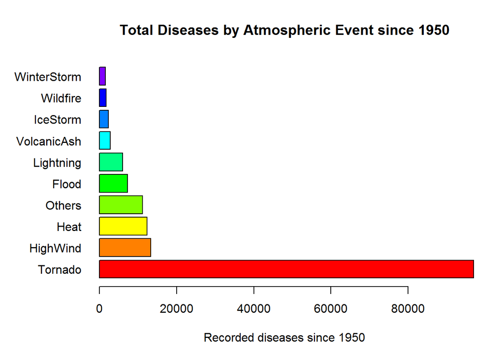

```r
StormData_HealthGraph <- StormData_HealthSUM
StormData_HealthGraph[ StormData_HealthGraph$SUM < (sum(StormData_HealthGraph$SUM) * 0.01), "EVTYPE"] <- "Others"
StormData_HealthGraph <- arrange( summarise( group_by( StormData_HealthGraph, EVTYPE), SUM = sum( SUM) ) , desc(SUM))

# Autoadjust the margins
linch <-  max(strwidth(StormData_HealthGraph$EVTYPE, "inch")+0.4, na.rm = TRUE)
par(mai=c(1.02,linch,0.82,0.42))

graph1 <- barplot(height = StormData_HealthGraph$SUM, names.arg = StormData_HealthGraph$EVTYPE ,horiz=TRUE, main = "Total Diseases by Atmospheric Event since 1950", xlab = "Recorded diseases since 1950", col=rainbow(12), las=1)
```

## 2.2. Economic Impact

As we did before I we create a new subset of columns from the data frame StormData.

```r
StormData_Econ <- StormData[ complete.cases( StormData [ , c("EVTYPE","PROPDMG","PROPDMGEXP","CROPDMG","CROPDMGEXP") ] ), ]
```

Next steps will be:  
1. Add the columns for the factors and the partial calculations for each row:

```r
StormData_Econ$PFAC <- StormData_Econ [ , "PROPDMGEXP"]
StormData_Econ$CFAC <- StormData_Econ [ , "CROPDMGEXP"]
StormData_Econ$Monetary <- 0
StormData_Econ$Properies <- 0
```

I have considered the Total Economical Impact, for each event, as the sum of PROPDMG and CROPDMG. Every of these fields will be multiplied for the corresponding factor.

```r
StormData_Econ$Monetary <- StormData_Econ$PROPDMG * StormData_Econ$PROPDMGEXP + StormData_Econ$CROPDMG * StormData_Econ$CROPDMGEXP
StormData_Econ$PROPTotal <- StormData_Econ$PROPDMG * StormData_Econ$PROPDMGEXP
StormData_Econ$CROPTotal <- StormData_Econ$CROPDMG * StormData_Econ$CROPDMGEXP
```

Before calculate the total amount for each event, to simplify our data frame I have select just the necessary columns. Due the obtained values the final impact will be given in Billions of dollars:

```r
# Our final data frame
StormData_Econ <- StormData_Econ[ , c("EVTYPE","Monetary","PROPTotal","CROPTotal")]

# We calculate the total economical impact of every event type. We arrange the resulting data frame by the descending sum of
# these factors. The result will be in Billions of Dollars and Thousens of houses

StormData_EconSUM <- arrange(summarise ( group_by( StormData_Econ , EVTYPE ), Monetary = sum( Monetary) / 10^9, Properties = sum(PROPTotal)/10^9, Crop = sum(CROPTotal)/10^9 ) , desc(Monetary, Properties, Crop))
```

Now I can calculate the worst atmospheric event for each category: Total, Properties and Crops.

```r
# The worst is Total Loss:
Evtype_Monetary <- as.character( StormData_EconSUM[ StormData_EconSUM$Monetary == max(StormData_EconSUM$Monetary) , "EVTYPE"] )
Evtype_MonetaryValue <- round(as.numeric(StormData_EconSUM[ StormData_EconSUM$Monetary == max(StormData_EconSUM$Monetary) , "Monetary"]) , 2)

# The worst in term of Properties Damaged:
Evtype_Properties <- as.character(StormData_EconSUM[ StormData_EconSUM$Properties == max(StormData_EconSUM$Properties) , "EVTYPE" ])
Evtype_PropertiesValue <- round( as.numeric(StormData_EconSUM[ StormData_EconSUM$Properties == max(StormData_EconSUM$Properties) , "Properties"]) , 2)

# The result  in term of Crops Damaged:
Evtype_Crop <- as.character(StormData_EconSUM[ StormData_EconSUM$Crop == max(StormData_EconSUM$Crop) , "EVTYPE"])
Evtype_CropValue <- round( as.numeric(StormData_EconSUM[ StormData_EconSUM$Crop == max(StormData_EconSUM$Crop) , "Crop"]) , 2)
```

The worst event type, in terms of Total Economical Impact, is **Flood** with a total of **161.44** Billions of dollars in loos.

The following plot represent the total loss for the Events whith the highest numbers of them. To reduce the number of categories I have merged all the categories with loss below the 1% of the total into a new category called *“Others”*.

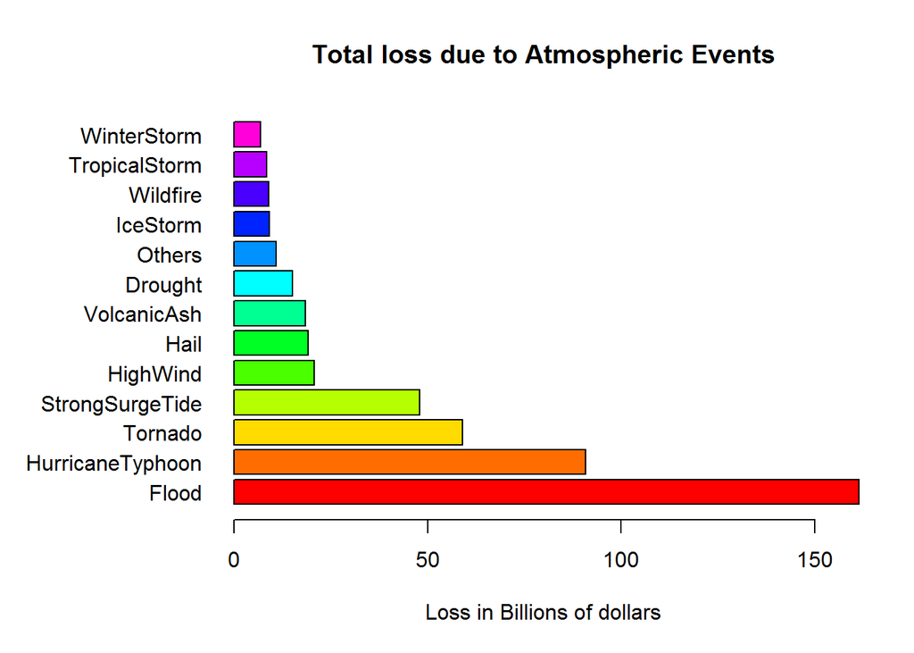

```r
# Now we create two plots. One for the total Economic Value and the other will be a double char for the impact in properties and crops.

StormData_EcoGraphTotal <- StormData_EconSUM[,c(1,2)]
## Graph1 : Total loss for Atmospheric events in billions of dollars.
# To reduce the categories I will merge all cathegories that represent less that 1% of the total deads.

StormData_EcoGraphTotal[ StormData_EcoGraphTotal$Monetary < ( sum( StormData_EcoGraphTotal$Monetary) * 0.01), "EVTYPE"] <- "Others"
StormData_EcoGraphTotal <- arrange( summarise( group_by( StormData_EcoGraphTotal, EVTYPE), Monetary = sum(Monetary) ) , desc(Monetary))

# Generate graph
linch <-  max(strwidth(StormData_EcoGraphTotal$EVTYPE, "inch")+0.4, na.rm = TRUE)
par(mai=c(1.02,linch,0.82,0.42))

graph1 <- barplot(height = StormData_EcoGraphTotal$Monetary, names.arg = StormData_EcoGraphTotal$EVTYPE , horiz=TRUE, main = "Total loss due to Atmospheric Events", xlab = "Loss in Billions of dollars", col=rainbow(14), las=1)
```

In terms of categories **Flood** was the event in terms of properties damaged with a total of **150.59** billions of dollars in loss. **Drought** was the worst event in terms of crop damaged with a total loss of **13.97** billions of dollars.

The following plot represent the total loss for the Events whith the highest numbers of them. To reduce the number of categories I have merged all the categories with loss below the 1% of the total into a new category called *“Others”*.

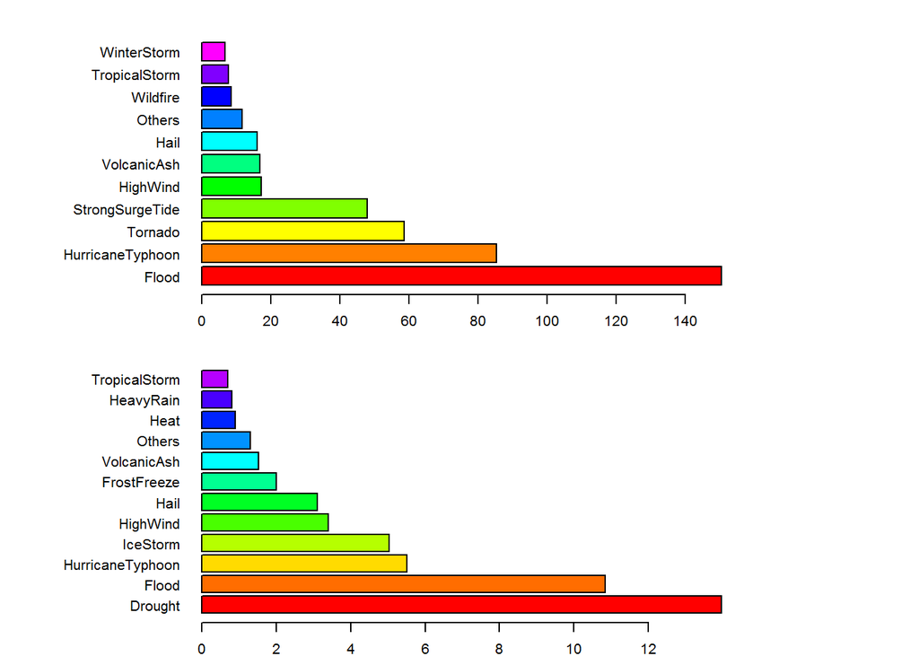

```r
StormData_EcoGraphProp <- StormData_EconSUM[,c(1,3)]
StormData_EcoGraphCrop <- StormData_EconSUM[,c(1,4)]

## Graph2 : Value in billions of dollars for Damaged Properties due to Atmospheric events.
# To reduce the categories I will merge all cathegories that represent less that 1% of the total deads.

StormData_EcoGraphProp [ StormData_EcoGraphProp$Properties < ( sum( StormData_EcoGraphProp$Properties) * 0.01), "EVTYPE"] <- "Others"
StormData_EcoGraphProp <- arrange( summarise( group_by( StormData_EcoGraphProp, EVTYPE), Properties = sum(Properties) ) , desc(Properties))

## Graph3 : Value in billions of dollars of Damaged Crops due to Atmospheric events.
# To reduce the categories I will merge all cathegories that represent less that 1% of the total deads.

StormData_EcoGraphCrop[ StormData_EcoGraphCrop$Crop < ( sum( StormData_EcoGraphCrop$Crop) * 0.01), "EVTYPE"] <- "Others"
StormData_EcoGraphCrop <- arrange( summarise( group_by( StormData_EcoGraphCrop, EVTYPE), Crop = sum(Crop) ) , desc(Crop))

# Generate graph

# Now we plot the last two graphs in a combined panel.

linch <-  max(strwidth(StormData_EcoGraphProp$EVTYPE, "inch")+0.4, na.rm = TRUE)
par(mfrow=c(2,1), mai=c(1.02,linch+0.4,0.82,0.42), pin = c(4,2), cex = 0.65)
barplot(height = StormData_EcoGraphProp$Properties, names.arg = StormData_EcoGraphProp$EVTYPE , horiz=TRUE, main = "Total loss in properties due to Atmospheric Events", xlab = "Loss in Billions of dollars", col=rainbow(12), las=1)
barplot(height = StormData_EcoGraphCrop$Crop, names.arg = StormData_EcoGraphCrop$EVTYPE , horiz=TRUE, main = "Total loss in crops due to Atmospheric Events", xlab = "Loss in Billions of dollars", col=rainbow(14), las=1)
```

# 3. Results

In terms of economical impact, **Flood** has cost to the United States a total of **161.44** Billions of dollars of direct loss. Analizing the different categories, **Flood** was the worst event for those who own a properties with a total of **150.59** billions of dollars in loss in damaged properties. However **Drought** is the event that farmer worries the most with a total of **13.97** billions of dollars of registered loss.

# 4. Extras

You will find the R script in my GitHub repostory. You can go there through that (link)[https://github.com/jjperez78/RepData_Assestment2]